# Red Wine Quality Analysis

# Final Plots and Summary

### Plot One

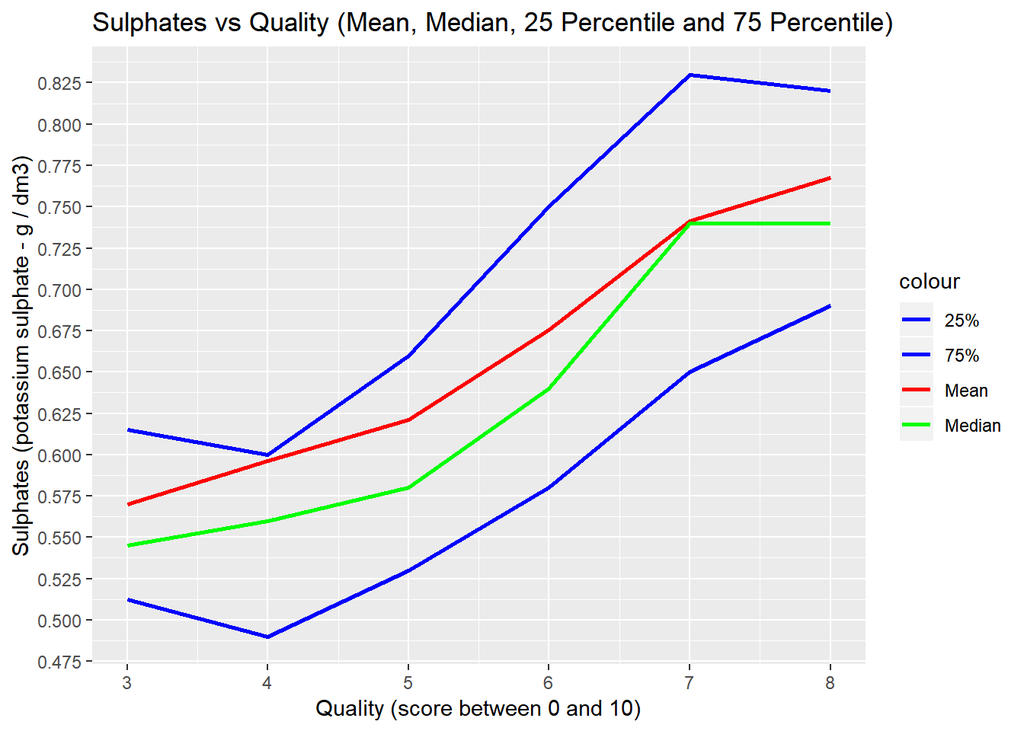

### Description One

In this graph we see the sulphates content vs the quality of wine. We see that as the sulphate content in wine increases the quality of wine also increases. the mean value shows a very linear relationship between the two values.

### Plot Two

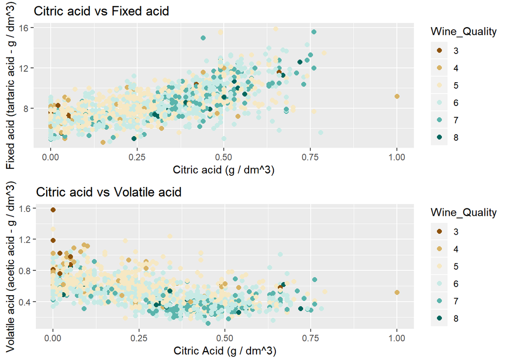

### Description Two

In the first plot we see that good wines have the high citric acid value and also high fixed acid value.

In the second graph we observe that for a better quality wine the citric acid has high content value but the lower volatile content. These two acids have opposite trends for the quality.

### Plot Three

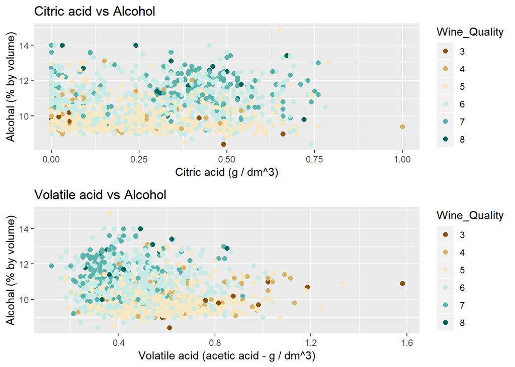

### Description Three

In both the plots we see the trends of previous plots. Also when the acid level is a constant the quality of wine increases as the alcohol content is increasing. This shows a strong positive correlation between alcohol and wine qulality.

# Reflection

The citric acid can add “freshness” and flavour to a wine and we saw that the quality of wine increases with the increase in citric acid content in wine.

Similarly, the high value of volatile acid (acetic acid) can lead to unpleasant, vinegar taste and in our plot we observed that in high quality wine this acid content is low.

Also, the pH value is low in good wines, in other words, the acidity of wine is high in good quality wines.

In most cases, other values remains constant the increase in alcohol content increases the wine quality.

And, sugar, salt, density all have a negative relationships to wine quality

In the plots therse are too many outliers, as we know that the data is biased with more observations for normal wines, we may analyze those outlier values for the wine quality.

# Citations

[1] P. Cortez, A. Cerdeira, F. Almeida, T. Matos and J. Reis. Modeling wine preferences by data mining from physicochemical properties. In Decision Support Systems, Elsevier, 47(4):547-553. ISSN: 0167-9236. Available at: [@Elsevier] http://dx.doi.org/10.1016/j.dss.2009.05.016 [Pre-press (pdf)] http://www3.dsi.uminho.pt/pcortez/winequality09.pdf [bib] http://www3.dsi.uminho.pt/pcortez/dss09.bib